# 红酒品质的影响因素与分类预测

学号：14307130391 姓名：孔镜棋 专业：理论与应用力学

关键字：红酒，机器学习，回归，热力图，决策树，向量机，svm，逻辑回归

## 1.1 导言

```python
import sklearn
import pandas as pd
import matplotlib.pyplot as plt
import seaborn as sns
import numpy as np
from sklearn import preprocessing
from sklearn import metrics
from sklearn import svm
from sklearn.svm import SVC
from sklearn.tree import DecisionTreeClassifier
from sklearn.metrics import roc_auc_score
from sklearn.linear_model import LogisticRegression
import scipy as sp
import warnings
warnings.filterwarnings('ignore')
%matplotlib inline
import nltk
```

## 1.2 数据获取与整理（清洗）

本次探究实验所使用的csv文件是从Kaggle.com的免费、公开Datasets上获得的，文件本身非常干净，没有任何缺失值或是错误的存在。

说实话，数据的获取与清洗这个过程非常锻炼人，也是日后数据分析中必不可少的关键一环。例如，仅仅以缺失项这一块来说，正常情况下有两类处理办法：一是直接删去缺失数据项；二是通过挖掘数据本身的规律，补上缺失值。此外，还可能会有需要对数据进行格式统一化的预处理等等操作。因此我对于所采用的csv文件非常干净这一点，是既觉得自己幸运，又觉得有些遗憾的。

```python
#导入csv文件，命名为data#
data = pd.read_csv('C:\winequality-red.csv', dtype={'quality':int})
data.head()
```

|  | fixed acidity | volatile acidity | citric acid | residual sugar | chlorides | free sulfur dioxide | total sulfur dioxide | density | pH | sulphates | alcohol | quality |
| --- | --- | --- | --- | --- | --- | --- | --- | --- | --- | --- | --- | --- |
| 0 | 7.4 | 0.70 | 0.00 | 1.9 | 0.076 | 11.0 | 34.0 | 0.9978 | 3.51 | 0.56 | 9.4 | 5 |
| 1 | 7.8 | 0.88 | 0.00 | 2.6 | 0.098 | 25.0 | 67.0 | 0.9968 | 3.20 | 0.68 | 9.8 | 5 |
| 2 | 7.8 | 0.76 | 0.04 | 2.3 | 0.092 | 15.0 | 54.0 | 0.9970 | 3.26 | 0.65 | 9.8 | 5 |
| 3 | 11.2 | 0.28 | 0.56 | 1.9 | 0.075 | 17.0 | 60.0 | 0.9980 | 3.16 | 0.58 | 9.8 | 6 |
| 4 | 7.4 | 0.70 | 0.00 | 1.9 | 0.076 | 11.0 | 34.0 | 0.9978 | 3.51 | 0.56 | 9.4 | 5 |

## 1.3 数据分析

本次数据分析主要以‘quality’，即'品质',作为分析过程中的主要关注点。

### 1.3.1 数据整体情况

```python
#data的初始基本信息#
data.describe()
```

|  | fixed acidity | volatile acidity | citric acid | residual sugar | chlorides | free sulfur dioxide | total sulfur dioxide | density | pH | sulphates | alcohol | quality |
| --- | --- | --- | --- | --- | --- | --- | --- | --- | --- | --- | --- | --- |
| count | 1599.000000 | 1599.000000 | 1599.000000 | 1599.000000 | 1599.000000 | 1599.000000 | 1599.000000 | 1599.000000 | 1599.000000 | 1599.000000 | 1599.000000 | 1599.000000 |
| mean | 8.319637 | 0.527821 | 0.270976 | 2.538806 | 0.087467 | 15.874922 | 46.467792 | 0.996747 | 3.311113 | 0.658149 | 10.422983 | 5.636023 |
| std | 1.741096 | 0.179060 | 0.194801 | 1.409928 | 0.047065 | 10.460157 | 32.895324 | 0.001887 | 0.154386 | 0.169507 | 1.065668 | 0.807569 |
| min | 4.600000 | 0.120000 | 0.000000 | 0.900000 | 0.012000 | 1.000000 | 6.000000 | 0.990070 | 2.740000 | 0.330000 | 8.400000 | 3.000000 |
| 25% | 7.100000 | 0.390000 | 0.090000 | 1.900000 | 0.070000 | 7.000000 | 22.000000 | 0.995600 | 3.210000 | 0.550000 | 9.500000 | 5.000000 |
| 50% | 7.900000 | 0.520000 | 0.260000 | 2.200000 | 0.079000 | 14.000000 | 38.000000 | 0.996750 | 3.310000 | 0.620000 | 10.200000 | 6.000000 |
| 75% | 9.200000 | 0.640000 | 0.420000 | 2.600000 | 0.090000 | 21.000000 | 62.000000 | 0.997835 | 3.400000 | 0.730000 | 11.100000 | 6.000000 |
| max | 15.900000 | 1.580000 | 1.000000 | 15.500000 | 0.611000 | 72.000000 | 289.000000 | 1.003690 | 4.010000 | 2.000000 | 14.900000 | 8.000000 |

从上表可以获知红酒的各项指标的基本信息，比如平均值，四分位值，最大值等。

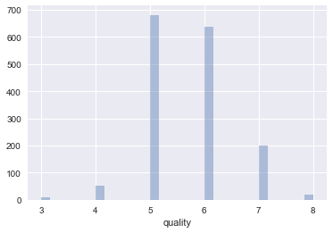

```python
#查看quality的总体分布情况
f1 = sns.distplot(data['quality'], kde=False, rug=False, )
```

可以看到，红酒的quality主要集中在5、6这两个取值，中位数为6，平均值为5.64,。

### 1.3.2 各指标的相关系数矩阵

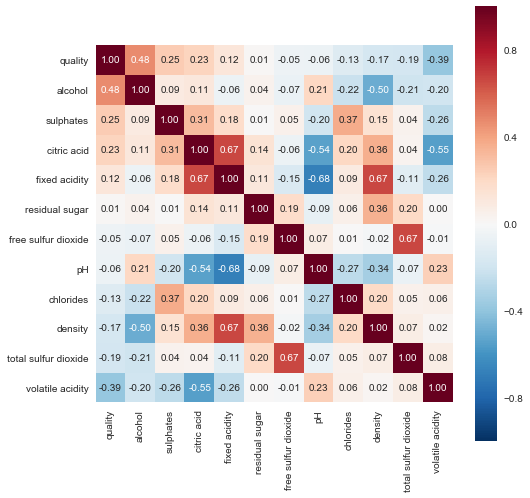

```python
f2 = plt.subplots(figsize=(8, 8))
a = 12
corrmat = data.corr()
cols = corrmat.nlargest(a, 'quality')['quality'].index
sns.set(font_scale=1)
cm = np.corrcoef(data[cols].values.T)
hm = sns.heatmap(cm, cbar=True, annot=True, square=True, fmt='.2f', annot_kws={'size': 10},
yticklabels=cols.values, xticklabels=cols.values)
plt.show()
```

为了便于阅读，代码中已经令各指标按照与‘quality’的相关系数由大到小进行排列。因此我们可以先看第一行（列）。整体来说，各个指标与‘quality’的相关程度都不算太高，其中相关程度最大的是‘alcohol’，其次是‘volatile acidity’。

指标之间也产生了一定的相关性。初步观察有以下几对：'fixed acidity - critic acid'(0.67); 'pH - critic acid'(-0.54); 'pH - fixed acidity'(-0.68); 'density - alcohol'(-0.50); 'density - fixed acidity'(0.67);'total sulfer dioxide - free sulfer dioxide'(0.67);'volatile acidity - critic acid'(-0.55);

这当中，pH与各类acid（酸）之间的相关性很好理解；酒精的密度比较小，所以相应的，红酒的alcohol（酒精含量）与它的density（密度）呈负相关；total sulfer dioxide（总二氧化硫）与free sulfer dioxide（自由二氧化硫）之间，作为分量和总量，也很好理解。

只有'density - fixed acidity'(0.67)这一组，无法说出它们之间的直接联系。

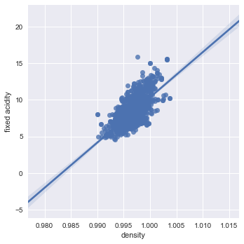

```python
#作density - fixed acidity散点图，并用直线拟合
sns.lmplot(x="density",y = "fixed acidity", data=data)
plt.show()
```

由上图可以看出，‘fixed acidity’与‘density’之间存在着很强的正向线性关系。

### 1.3.3 各指标与‘quality’之间的散点分布图和拟合

```python
quality = ['quality']
predictors=[x for x in list(data.columns) if x not in quality]
```

```python
predictors
```

```
['fixed acidity',
 'volatile acidity',
 'citric acid',
 'residual sugar',
 'chlorides',
 'free sulfur dioxide',
 'total sulfur dioxide',
 'density',
 'pH',
 'sulphates',
 'alcohol']
```

#### 1.3.3.1 以'quality'为纵轴

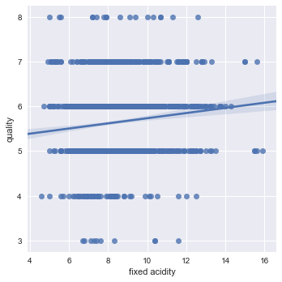

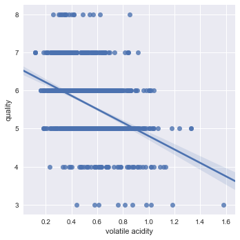

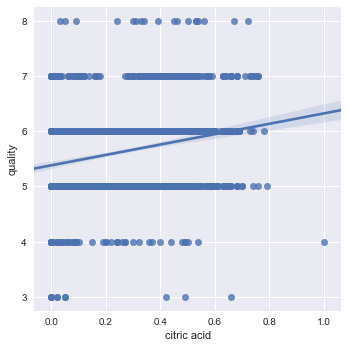

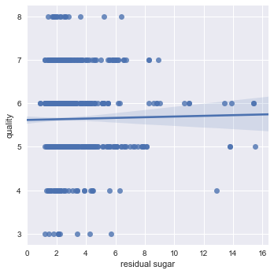

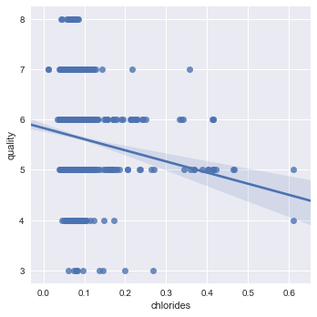

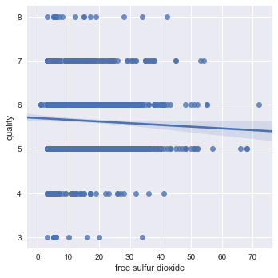

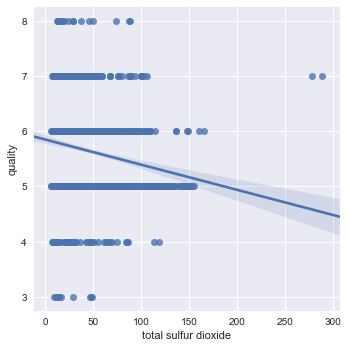

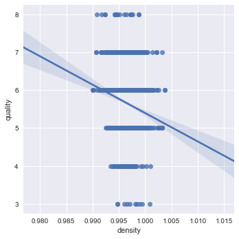

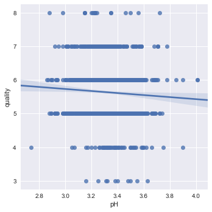

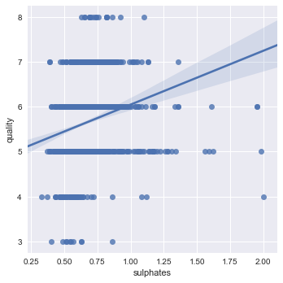

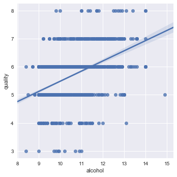

```python
for i in predictors:
    da = pd.concat([data['quality'], data[i]], axis=1)
    sns.lmplot(y="quality",x = i, data=data)
```

#### 1.3.3.2 以'quality'为横轴

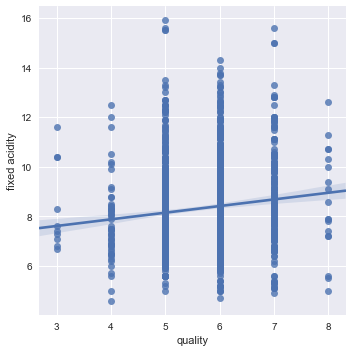

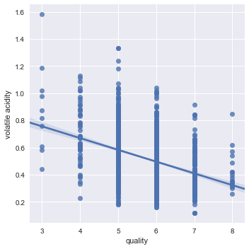

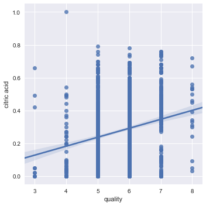

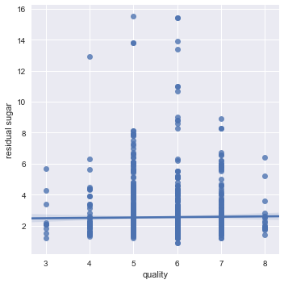

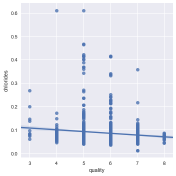

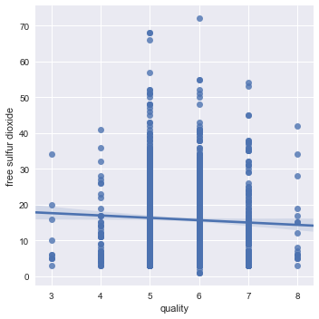

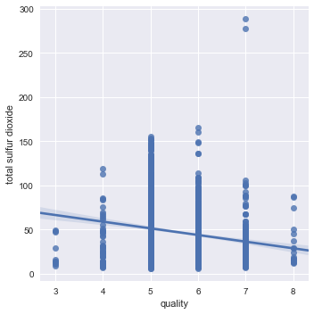

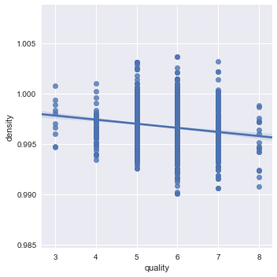

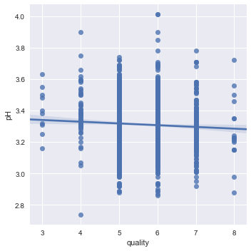

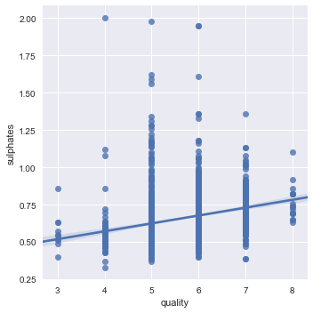

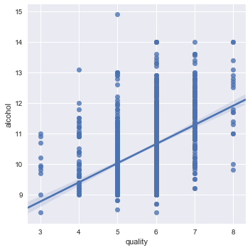

```python
for i in predictors:
    da = pd.concat([data['quality'], data[i]], axis=1)
    sns.lmplot(x="quality",y = i, data=data)
```

从上图中我们已经可以比较清楚的看到各个指标之前与‘quality’之间的关系，不再一个个地列举；

1.3.3这一节有这样的两个问题想要探讨一下：

（1）从散点图上不难发现，存在着许多离群点，几乎每一张图中都有。由此，部分指标与‘quality’之间的相关程度不够高，很有可能是因为离群点的存在；如果能够把对应的离群去除，相关系数应该能有一定的提升。但是，剔除的尺度，以及相对较大的工作量，让我暂时没有选择深入。

（2）我是先以‘quality’为纵坐标，发现线性拟合的效果不是特别好，而后我将其用在横轴上，线性拟合的效果看起来是变好了，受离群点的影响也变小了。

### 1.3.4 “好酒”和“坏酒”

由之前的‘quality’分布直方图可知，‘quality’呈正态分布形状，中间（5、6分）多，两头（3、4/7、8分）少。

于是，不妨把7、8分的红酒定义为“好酒”，3、4分的红酒定位为“坏酒”。再将二者与整体水平对比，看看能有什么发现。

#### 1.3.4.1 准备工作

```python
#创建一个新的df，“好酒”
data_good = data[data.quality.isin(['7','8'])]
data_good.head()
```

|  | fixed acidity | volatile acidity | citric acid | residual sugar | chlorides | free sulfur dioxide | total sulfur dioxide | density | pH | sulphates | alcohol | quality |
| --- | --- | --- | --- | --- | --- | --- | --- | --- | --- | --- | --- | --- |
| 7 | 7.3 | 0.65 | 0.00 | 1.2 | 0.065 | 15.0 | 21.0 | 0.9946 | 3.39 | 0.47 | 10.0 | 7 |
| 8 | 7.8 | 0.58 | 0.02 | 2.0 | 0.073 | 9.0 | 18.0 | 0.9968 | 3.36 | 0.57 | 9.5 | 7 |
| 16 | 8.5 | 0.28 | 0.56 | 1.8 | 0.092 | 35.0 | 103.0 | 0.9969 | 3.30 | 0.75 | 10.5 | 7 |
| 37 | 8.1 | 0.38 | 0.28 | 2.1 | 0.066 | 13.0 | 30.0 | 0.9968 | 3.23 | 0.73 | 9.7 | 7 |
| 62 | 7.5 | 0.52 | 0.16 | 1.9 | 0.085 | 12.0 | 35.0 | 0.9968 | 3.38 | 0.62 | 9.5 | 7 |

```python
#创建一个新的df，“坏酒”
data_bad = data[data.quality.isin(['3','4'])]
data_bad.head()
```

|  | fixed acidity | volatile acidity | citric acid | residual sugar | chlorides | free sulfur dioxide | total sulfur dioxide | density | pH | sulphates | alcohol | quality |
| --- | --- | --- | --- | --- | --- | --- | --- | --- | --- | --- | --- | --- |
| 18 | 7.4 | 0.590 | 0.08 | 4.4 | 0.086 | 6.0 | 29.0 | 0.9974 | 3.38 | 0.50 | 9.0 | 4 |
| 38 | 5.7 | 1.130 | 0.09 | 1.5 | 0.172 | 7.0 | 19.0 | 0.9940 | 3.50 | 0.48 | 9.8 | 4 |
| 41 | 8.8 | 0.610 | 0.30 | 2.8 | 0.088 | 17.0 | 46.0 | 0.9976 | 3.26 | 0.51 | 9.3 | 4 |
| 45 | 4.6 | 0.520 | 0.15 | 2.1 | 0.054 | 8.0 | 65.0 | 0.9934 | 3.90 | 0.56 | 13.1 | 4 |
| 73 | 8.3 | 0.675 | 0.26 | 2.1 | 0.084 | 11.0 | 43.0 | 0.9976 | 3.31 | 0.53 | 9.2 | 4 |

```python
#整体的各项平均值
mean1 = data.mean()
mean1
```

```
fixed acidity            8.319637
volatile acidity         0.527821
citric acid              0.270976
residual sugar           2.538806
chlorides                0.087467
free sulfur dioxide     15.874922
total sulfur dioxide    46.467792
density                  0.996747
pH                       3.311113
sulphates                0.658149
alcohol                 10.422983
quality                  5.636023
dtype: float64
```

```python
#好酒的各项平均值
mean2 = data_good.mean()
mean2
```

```
fixed acidity            8.847005
volatile acidity         0.405530
citric acid              0.376498
residual sugar           2.708756
chlorides                0.075912
free sulfur dioxide     13.981567
total sulfur dioxide    34.889401
density                  0.996030
pH                       3.288802
sulphates                0.743456
alcohol                 11.518049
quality                  7.082949
dtype: float64
```

```python
#坏酒的各项平均值
mean3 = data_bad.mean()
mean3
```

```
fixed acidity            7.871429
volatile acidity         0.724206
citric acid              0.173651
residual sugar           2.684921
chlorides                0.095730
free sulfur dioxide     12.063492
total sulfur dioxide    34.444444
density                  0.996689
pH                       3.384127
sulphates                0.592222
alcohol                 10.215873
quality                  3.841270
dtype: float64
```

```python
#合并到同一个df里
pingjun=pd.DataFrame([mean1,mean2,mean3]).T
pingjun.drop(pingjun.index[11],inplace=True)
pingjun.columns = ['common','good','bad']
pingjun
```

|  | common | good | bad |
| --- | --- | --- | --- |
| fixed acidity | 8.319637 | 8.847005 | 7.871429 |
| volatile acidity | 0.527821 | 0.405530 | 0.724206 |
| citric acid | 0.270976 | 0.376498 | 0.173651 |
| residual sugar | 2.538806 | 2.708756 | 2.684921 |
| chlorides | 0.087467 | 0.075912 | 0.095730 |
| free sulfur dioxide | 15.874922 | 13.981567 | 12.063492 |
| total sulfur dioxide | 46.467792 | 34.889401 | 34.444444 |
| density | 0.996747 | 0.996030 | 0.996689 |
| pH | 3.311113 | 3.288802 | 3.384127 |
| sulphates | 0.658149 | 0.743456 | 0.592222 |
| alcohol | 10.422983 | 11.518049 | 10.215873 |

#### 1.3.4.2 图表分析

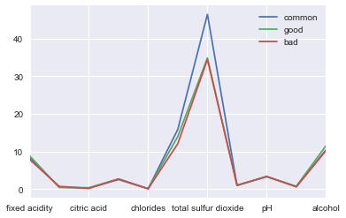

```python
pingjun.plot(kind = 'line', use_index = True, title = False)
plt.show()
```

这张折线图整合了“common”，“good”和“bad”三个种类之间的各项指标，但是由于‘total sulfer dioxide’这一项的数值远大于其他项目，令折线图看起来重合度较高，于是采用了计算差距百分比的方法，见下。

```python
rate_bad = (mean3 - mean1)/mean1
rate_good = (mean2 - mean1)/mean1
rate=pd.DataFrame([rate_good,rate_bad]).T
rate.columns = ['good','bad']
rate
```

|  | good | bad |
| --- | --- | --- |
| fixed acidity | 0.063388 | -0.053874 |
| volatile acidity | -0.231690 | 0.372069 |
| citric acid | 0.389415 | -0.359164 |
| residual sugar | 0.066941 | 0.057553 |
| chlorides | -0.132097 | 0.094477 |
| free sulfur dioxide | -0.119267 | -0.240091 |
| total sulfur dioxide | -0.249170 | -0.258746 |
| density | -0.000719 | -0.000058 |
| pH | -0.006738 | 0.022051 |
| sulphates | 0.129617 | -0.100170 |
| alcohol | 0.105063 | -0.019871 |
| quality | 0.256728 | -0.318443 |

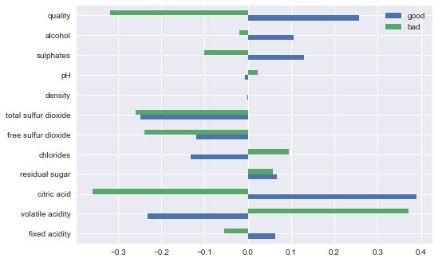

```python
rate.plot(kind = 'barh')
plt.show()
```

由上图可以看到，在‘alcohol’，‘sulphates’，‘pH’，‘chlorides’，‘critic acid’，‘volatile acidity’和‘fixed acidity’方面，“好酒”与“坏酒”基本呈现出相反的物质含量。比如，“好酒”的‘critic acid’（柠檬酸）含量比整体高38.9%，“坏酒”的含量比整体低36.0%。

然而，在‘sulfur dioxide’系列和‘residual sugar’方面，“好酒”和“坏酒”表现出了一样的趋势。因此说明之前，之前对其使用的一元线性回归，是不准确的。

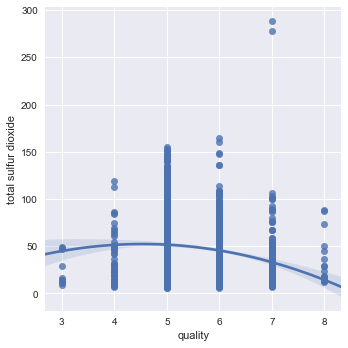

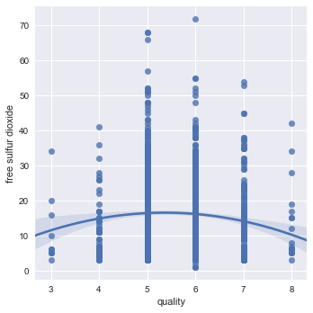

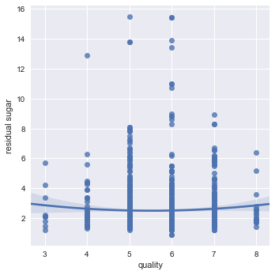

```python
sns.lmplot(y="total sulfur dioxide",x = "quality", data=data, order = 2)
sns.lmplot(y="free sulfur dioxide",x = "quality", data=data, order = 2)
sns.lmplot(y="residual sugar",x = "quality", data=data, order = 2)
plt.show()
```

重新对‘total sulfur dioxide’和‘residual sugar’做回归，这次使用了二次多项式。效果还不错。

### 1.3.5 利用机器学习分类“好酒”

我发现利用我现有的数据，和我现有的知识水平，已经比较难再挖掘出数据与数据之间的联系。因此接下来我使用了scikit-learn里面的函数，分别运用了三种算法：决策树、向量机和逻辑回归，尝试了一下机器学习的入门。

我将‘quality’大于6.5，也就是为7或8的红酒定义为good，赋值为1；‘quality’小于6.5的红酒赋值为0；并将整个csv数据拆分为训练集和测试集，想试验一下在本题的语境下，哪类算法有更高的准确度。

#### 1.3.5.1 数据准备（赋值）

```python
#赋值
data1 = data
sep=6.5
data1.loc[data['quality']<sep, ['quality']]=0
data1.loc[data['quality']>sep, ['quality']]=1
data1.head(10)
```

|  | fixed acidity | volatile acidity | citric acid | residual sugar | chlorides | free sulfur dioxide | total sulfur dioxide | density | pH | sulphates | alcohol | quality |
| --- | --- | --- | --- | --- | --- | --- | --- | --- | --- | --- | --- | --- |
| 0 | 7.4 | 0.70 | 0.00 | 1.9 | 0.076 | 11.0 | 34.0 | 0.9978 | 3.51 | 0.56 | 9.4 | 0 |
| 1 | 7.8 | 0.88 | 0.00 | 2.6 | 0.098 | 25.0 | 67.0 | 0.9968 | 3.20 | 0.68 | 9.8 | 0 |
| 2 | 7.8 | 0.76 | 0.04 | 2.3 | 0.092 | 15.0 | 54.0 | 0.9970 | 3.26 | 0.65 | 9.8 | 0 |
| 3 | 11.2 | 0.28 | 0.56 | 1.9 | 0.075 | 17.0 | 60.0 | 0.9980 | 3.16 | 0.58 | 9.8 | 0 |
| 4 | 7.4 | 0.70 | 0.00 | 1.9 | 0.076 | 11.0 | 34.0 | 0.9978 | 3.51 | 0.56 | 9.4 | 0 |
| 5 | 7.4 | 0.66 | 0.00 | 1.8 | 0.075 | 13.0 | 40.0 | 0.9978 | 3.51 | 0.56 | 9.4 | 0 |
| 6 | 7.9 | 0.60 | 0.06 | 1.6 | 0.069 | 15.0 | 59.0 | 0.9964 | 3.30 | 0.46 | 9.4 | 0 |
| 7 | 7.3 | 0.65 | 0.00 | 1.2 | 0.065 | 15.0 | 21.0 | 0.9946 | 3.39 | 0.47 | 10.0 | 1 |
| 8 | 7.8 | 0.58 | 0.02 | 2.0 | 0.073 | 9.0 | 18.0 | 0.9968 | 3.36 | 0.57 | 9.5 | 1 |
| 9 | 7.5 | 0.50 | 0.36 | 6.1 | 0.071 | 17.0 | 102.0 | 0.9978 | 3.35 | 0.80 | 10.5 | 0 |

#### 1.3.5.2 数据准备（训练集/测试集）

```python
train = data1.sample(frac=0.7, random_state=886)
test = data1[data1.index.isin(train.index)==False].copy()
```

```python
train.head()
```

|  | fixed acidity | volatile acidity | citric acid | residual sugar | chlorides | free sulfur dioxide | total sulfur dioxide | density | pH | sulphates | alcohol | quality |
| --- | --- | --- | --- | --- | --- | --- | --- | --- | --- | --- | --- | --- |
| 830 | 7.5 | 0.685 | 0.07 | 2.5 | 0.058 | 5.0 | 9.0 | 0.99632 | 3.38 | 0.55 | 10.9 | 0 |
| 1090 | 10.0 | 0.260 | 0.54 | 1.9 | 0.083 | 42.0 | 74.0 | 0.99451 | 2.98 | 0.63 | 11.8 | 1 |
| 1120 | 7.9 | 0.540 | 0.34 | 2.5 | 0.076 | 8.0 | 17.0 | 0.99235 | 3.20 | 0.72 | 13.1 | 1 |
| 543 | 11.2 | 0.660 | 0.24 | 2.5 | 0.085 | 16.0 | 53.0 | 0.99930 | 3.06 | 0.72 | 11.0 | 0 |
| 1543 | 11.1 | 0.440 | 0.42 | 2.2 | 0.064 | 14.0 | 19.0 | 0.99758 | 3.25 | 0.57 | 10.4 | 0 |

```python
test.head()
```

|  | fixed acidity | volatile acidity | citric acid | residual sugar | chlorides | free sulfur dioxide | total sulfur dioxide | density | pH | sulphates | alcohol | quality |
| --- | --- | --- | --- | --- | --- | --- | --- | --- | --- | --- | --- | --- |
| 1 | 7.8 | 0.88 | 0.00 | 2.6 | 0.098 | 25.0 | 67.0 | 0.9968 | 3.20 | 0.68 | 9.8 | 0 |
| 3 | 11.2 | 0.28 | 0.56 | 1.9 | 0.075 | 17.0 | 60.0 | 0.9980 | 3.16 | 0.58 | 9.8 | 0 |
| 4 | 7.4 | 0.70 | 0.00 | 1.9 | 0.076 | 11.0 | 34.0 | 0.9978 | 3.51 | 0.56 | 9.4 | 0 |
| 8 | 7.8 | 0.58 | 0.02 | 2.0 | 0.073 | 9.0 | 18.0 | 0.9968 | 3.36 | 0.57 | 9.5 | 1 |
| 14 | 8.9 | 0.62 | 0.18 | 3.8 | 0.176 | 52.0 | 145.0 | 0.9986 | 3.16 | 0.88 | 9.2 | 0 |

```python
y_train = train[quality]
y_test = test[quality]
X_train = train[predictors]
X_test = test[predictors]
```

#### 1.3.5.3 使用模型并分类

```python
#决策树
clf1 = DecisionTreeClassifier()
clf1.fit(X_train, y_train)
print(clf1)
expected1 = y_test
predicted1 = clf1.predict(X_test)
```

```
DecisionTreeClassifier(class_weight=None, criterion='gini', max_depth=None,
            max_features=None, max_leaf_nodes=None,
            min_impurity_split=1e-07, min_samples_leaf=1,
            min_samples_split=2, min_weight_fraction_leaf=0.0,
            presort=False, random_state=None, splitter='best')
```

```python
#SVM
clf2 = SVC()
clf2.fit(X_train, y_train)
print(clf2)
expected2 = y_test
predicted2 = clf2.predict(X_test)
```

[output not shown]

```python
#逻辑回归
clf3 = LogisticRegression()
clf3.fit(X_train, y_train)
print(clf3)
expected3 = y_test
predicted3 = clf3.predict(X_test)
```

```
LogisticRegression(C=1.0, class_weight=None, dual=False, fit_intercept=True,
          intercept_scaling=1, max_iter=100, multi_class='ovr', n_jobs=1,
          penalty='l2', random_state=None, solver='liblinear', tol=0.0001,
          verbose=0, warm_start=False)
```